# An Analysis of Harmful Fuel Type Gas Emissions, Peer Review

### Reviewed by Breton Shindel

# Summarization of the Report

*An Analysis of Harmful Fuel Type Gas Emissions* is a report that takes the audience onto the front lines of industrial efficiency, and environmental and human health stewardship. The report hypothesises that FuelType1 vehicles have a higher frequency of Co2 emmision than FuelType2 vehicles (FuelType1 being the dominant, fossil fuel group, FuelType2 consisting of more alternative fuels). The report defines FuelType1 and FuelType2 as follows:

- FuelType1"For single fuel vehicles, this will be the only fuel. For dual fuel vehicles, this will be the conventional fuel."
- FuelType2 - For dual fuel vehicles, this will be the alternative fuel (e.g. E85, Electricity, CNG, LPG). For single fuel vehicles, this field is not used

Each observation shows the details of a vehicle type and what types of fuel it consumes, how long charging takes, model details and more. The data appears to be merged with another dataset that provides information on general trends such as annual consumption of petrolium for the corresponding fuel type.

If the the hypothesis of the report is accepted, we will have strong reason to believe that alternative fuels contribute less to CO2 emissions, thereby signaling an improvement in human and evironmental wellbeing by shifting industry to invest in FuelType2 vehicles. The report continues on to detail the specifications of alternative fuels found in FuelType2, visualize consumption of fuel types, prices of fuel types, combined miles per gallon per fuel and CO2 emissions per fuel type, and model the emission frequencies for vehicles.

In my review, I will focus on other effective ways to visualize and model the data and identify areas in the report that require further investigation into their findings.

```python
import pandas as pd
import numpy as np
import matplotlib.pyplot as plt
import seaborn as sns
import warnings
warnings.filterwarnings('ignore')
```

```python
%cd ~/Downloads
```

```
/Users/bretonshindel/Downloads
```

```python
pd.set_option('display.max_columns', None)
Data = pd.read_csv("HW3file.csv",)

print("Number of observations:", Data.shape[0])
print("Number of features:", Data.shape[1])
print('Range of years reported: ', Data['year'].min(), '-', Data['year'].max())

Data.head(3)
```

```
Number of observations: 29233
Number of features: 82
Range of years reported:  2004 - 2016
```

|  | Unnamed: 0 | barrels08 | barrelsA08 | charge120 | charge240 | city08 | city08U | cityA08 | cityA08U | cityCD | cityE | cityUF | co2 | co2A | co2TailpipeAGpm | co2TailpipeGpm | comb08 | comb08U | combA08 | combA08U | combE | combinedCD | combinedUF | cylinders | displ | drive | engId | feScore | fuelCost08 | … |
| --- | --- | --- | --- | --- | --- | --- | --- | --- | --- | --- | --- | --- | --- | --- | --- | --- | --- | --- | --- | --- | --- | --- | --- | --- | --- | --- | --- | --- | --- | --- |
| 0 | 0 | 18.304342 | 0 | 0 | 0 | 16 | 0 | 0 | 0 | 0 | 0 | 0 | -1 | -1 | 0 | 493.722222 | 18 | 0 | 0 | 0 | 0 | 0 | 0 | 6 | 3.0 | Rear-Wheel Drive | 0 | -1 | 1850 | … |
| 1 | 1 | 18.304342 | 0 | 0 | 0 | 16 | 0 | 0 | 0 | 0 | 0 | 0 | -1 | -1 | 0 | 493.722222 | 18 | 0 | 0 | 0 | 0 | 0 | 0 | 6 | 3.0 | Rear-Wheel Drive | 0 | -1 | 1850 | … |
| 2 | 2 | 18.304342 | 0 | 0 | 0 | 16 | 0 | 0 | 0 | 0 | 0 | 0 | -1 | -1 | 0 | 493.722222 | 18 | 0 | 0 | 0 | 0 | 0 | 0 | 6 | 3.2 | Rear-Wheel Drive | 0 | -1 | 1850 | … |

# Fuel Type Normality

My collegues begin their report by evaluating the normalcy of their data. My review will do the same, and find a more space-efficient way to show these visualizations. I also will include a density plot to coincide with the findings of the QQplots. Lastly, I will expand the report by evaluating the normalcy of other features that my collegues' report examines.

```python
import statsmodels.api as sm

%matplotlib inline

sns.set_context('poster')
sns.mpl.rc("figure", figsize=(12,6))
```

## Normality of CO2 Tailpipe Emissions

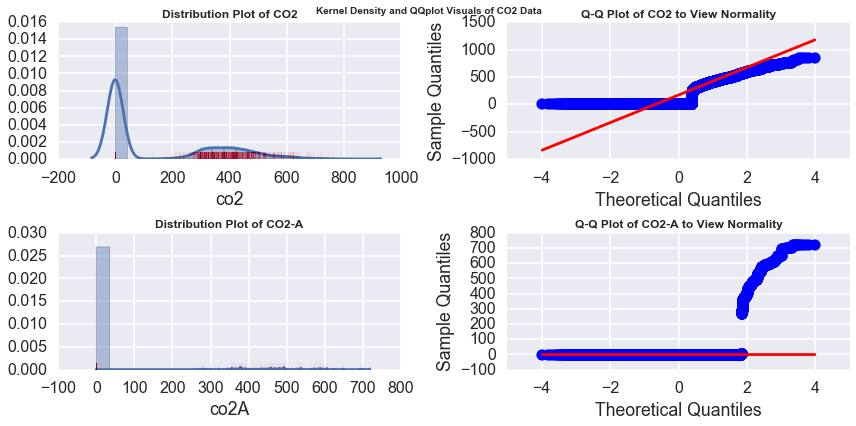

```python
fig, ax = plt.subplots(2, 2)

sns.distplot(Data.co2, bins=20, ax=ax[0, 0])
sns.rugplot(Data.co2, vertical=False, alpha= 0.005, color='red', ax=ax[0, 0])
ax[0, 0].set_title('Distribution Plot of CO2',  size=12, weight='bold')

sm.qqplot(Data.co2, line='q', ax=ax[0, 1])
ax[0, 1].set_title('Q-Q Plot of CO2 to View Normality', size=12, weight='bold')

sns.distplot(Data.co2A, bins=20, ax=ax[1, 0])
sns.rugplot(Data.co2A, vertical=False, alpha= 0.005, color='red', ax=ax[1, 0])
ax[1, 0].set_title('Distribution Plot of CO2-A',  size=12, weight='bold')

sm.qqplot(Data.co2A, line='q', ax=ax[1, 1])
ax[1, 1].set_title('Q-Q Plot of CO2-A to View Normality', size=12, weight='bold')

plt.tight_layout()
plt.suptitle('Kernel Density and QQplot Visuals of CO2 Data', size=36, weight='bold')
plt.legend()
```

## Normality of Barrel Consumption

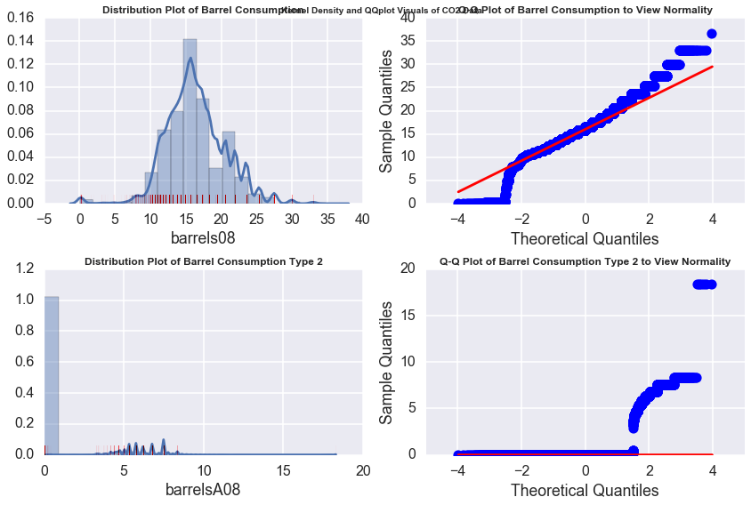

```python
fig, ax = plt.subplots(2, 2)

sns.distplot(Data.barrels08, bins=20, ax=ax[0, 0])
sns.rugplot(Data.barrels08, vertical=False, alpha= 0.005, color='red', ax=ax[0, 0])
ax[0, 0].set_title('Distribution Plot of Barrel Consumption',  size=12, weight='bold')

sm.qqplot(Data.barrels08, line='q', ax=ax[0, 1])
ax[0, 1].set_title('Q-Q Plot of Barrel Consumption to View Normality', size=12, weight='bold')

sns.distplot(Data.barrelsA08, bins=20, ax=ax[1, 0])
sns.rugplot(Data.barrelsA08, vertical=False, alpha= 0.005, color='red', ax=ax[1, 0])
ax[1, 0].set_title('Distribution Plot of Barrel Consumption Type 2',  size=12, weight='bold')

sm.qqplot(Data.barrelsA08, line='q', ax=ax[1, 1])
ax[1, 1].set_title('Q-Q Plot of Barrel Consumption Type 2 to View Normality', size=12, weight='bold')

plt.tight_layout()
plt.suptitle('Kernel Density and QQplot Visuals of Barrel Consumption Data', size=36, weight='bold')
plt.legend()
```

## Normality of Fuel Price

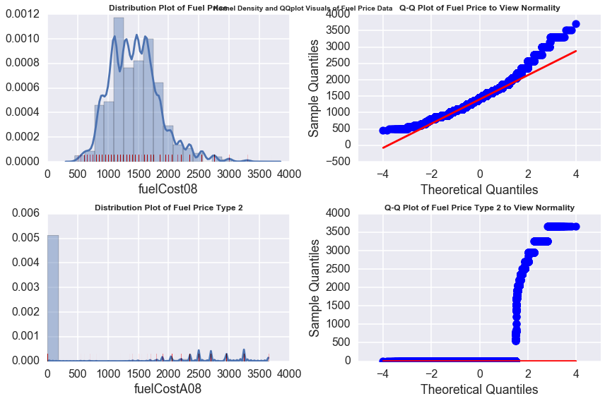

```python
fig, ax = plt.subplots(2, 2)

sns.distplot(Data.fuelCost08, bins=20, ax=ax[0, 0])
sns.rugplot(Data.fuelCost08, vertical=False, alpha= 0.005, color='red', ax=ax[0, 0])
ax[0, 0].set_title('Distribution Plot of Fuel Price',  size=12, weight='bold')

sm.qqplot(Data.fuelCost08, line='q', ax=ax[0, 1])
ax[0, 1].set_title('Q-Q Plot of Fuel Price to View Normality', size=12, weight='bold')

sns.distplot(Data.fuelCostA08, bins=20, ax=ax[1, 0])
sns.rugplot(Data.fuelCostA08, vertical=False, alpha= 0.005, color='red', ax=ax[1, 0])
ax[1, 0].set_title('Distribution Plot of Fuel Price Type 2',  size=12, weight='bold')

sm.qqplot(Data.fuelCostA08, line='q', ax=ax[1, 1])
ax[1, 1].set_title('Q-Q Plot of Fuel Price Type 2 to View Normality', size=12, weight='bold')

plt.tight_layout()
plt.suptitle('Kernel Density and QQplot Visuals of Fuel Price Data', size=36, weight='bold')
plt.legend()
```

## Normality of Combined MPG

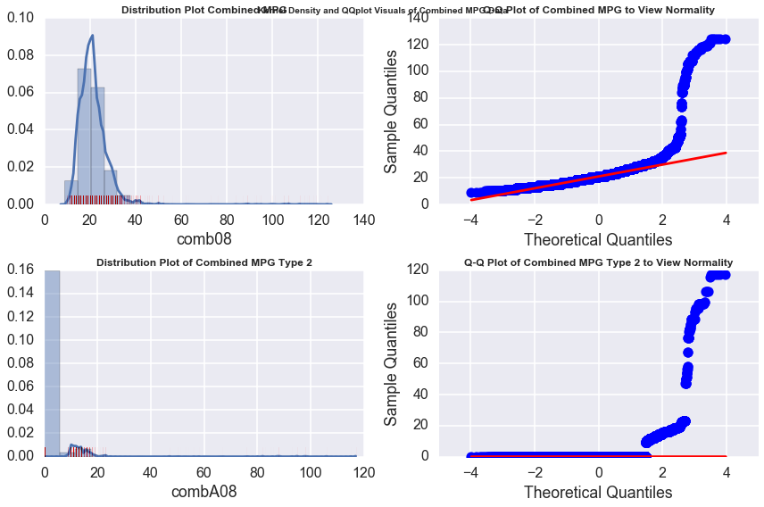

```python
fig, ax = plt.subplots(2, 2)

sns.distplot(Data.comb08, bins=20, ax=ax[0, 0])
sns.rugplot(Data.comb08, vertical=False, alpha= 0.005, color='red', ax=ax[0, 0])
ax[0, 0].set_title('Distribution Plot Combined MPG',  size=12, weight='bold')

sm.qqplot(Data.comb08, line='q', ax=ax[0, 1])
ax[0, 1].set_title('Q-Q Plot of Combined MPG to View Normality', size=12, weight='bold')

sns.distplot(Data.combA08, bins=20, ax=ax[1, 0])
sns.rugplot(Data.combA08, vertical=False, alpha= 0.005, color='red', ax=ax[1, 0])
ax[1, 0].set_title('Distribution Plot of Combined MPG Type 2',  size=12, weight='bold')

sm.qqplot(Data.combA08, line='q', ax=ax[1, 1])
ax[1, 1].set_title('Q-Q Plot of Combined MPG Type 2 to View Normality', size=12, weight='bold')

plt.tight_layout()
plt.suptitle('Kernel Density and QQplot Visuals of Combined MPG Data', size=36, weight='bold')
plt.legend()
```

## Findings

Examining the distributions of our data can give us a good idea whether or not our data is related, as well as giving us some warning signs about the data we're using. For instance, CO2 tailpipe emissions show a flat distribution with the highest density at 0, telling us that the majority of vehicles of both fuel types emit 0 emissions! This must be a significant inaccuracy in our data, and we will see later in the review that tailpipe emissions data will fail to provide us with a robust understanding of the differences of emissions between the two vehicle fuel types.

I also notice there is a trend of seeing normal distributions for fuel type 1 data, while fuel type 2 data spikes at 0 for most of its observations. Later in the review we will see that this is because fuel type 2 data is not seperated from fuel type 1 data, therefore there is a significantly high number of features that represent fuel type 2 data with 0s. If not addressed appropriately, the data will skew the visualizations and analyses to be done.

The report by my collegues provides a good start by identifying the lack of normality of the CO2 tailpipe emission data, and the repeating values in it. My review's aim is to expand the examination of normality onto more features, and to indentify how some distributions not being normal translates into issues with out dataset.

# Consumption

My collegue's report looks first at the change in fuel type consumption over time. Below I will recreate my collegue's time seires plots and merge them into one single visual. From here on I will also highlight the conventional fuel type 2 in red, and the alternative fuel type 2 in blue, to reflect the report's hypothesis that fuel type 2 contributes less to CO2 emissions and fuel type 1.

```python
co2_Year = Data.pivot_table('barrels08', index='year') # barrels08 - annual petroleum consumption in barrels for fuelType1 (1)
co2A_Year = Data.pivot_table('barrelsA08', index='year') # barrelsA08 - annual petroleum consumption in barrels for fuelType2 (1)
```

[figure not shown]

```python
sns.mpl.rc("figure", figsize=(12,6))

plt.plot(co2_Year, color='red', label='Fuel Type 1')

plt.plot(co2A_Year, color='blue', label='Fuel Type 2')

plt.title('Average Barrel Consumption for Fuel Types')
plt.show();
```

Unlike my collegues, I choose not to show a normalized plot of the data. The reason I like this plot a little better than the normalized plot is because this plot is simply more accurate to reality, from the reader's perspective. A normalized plot can be very useful, particularly when dealing with features that show barely any noticeable change to the human eye. But it often distorts reality. Here we can see plainly that consumption for barrels of fuel type 1 is steadily decreasing, while there is a small but significant uptick in consumption for barrels of fuel type 2.

There is another way of making this time series plot more powerful. Let's take a look.

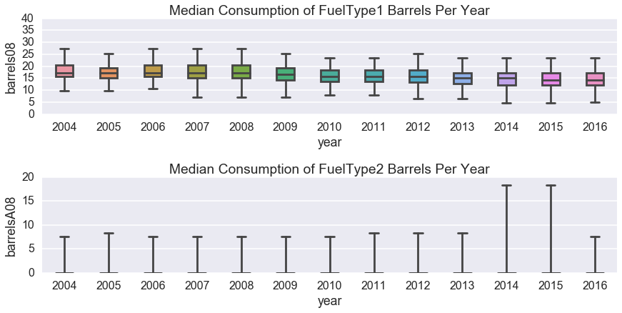

```python
fig, ax = plt.subplots(2, 1)

sns.boxplot(x='year', y='barrels08', data=Data, width=0.4, fliersize=0, orient='v', ax=ax[0])
ax[0].set_title('Median Consumption of FuelType1 Barrels Per Year')

sns.boxplot(x='year', y='barrelsA08', data=Data, width=0.4, fliersize=0, orient='v', ax=ax[1])
ax[1].set_title('Median Consumption of FuelType2 Barrels Per Year')

plt.tight_layout(pad=0.4, h_pad=2.0)
plt.show();
```

```python
Fuel1Cons_Data = Data[Data.barrels08 > 0]
Fuel2Cons_Data = Data[Data.barrelsA08 > 0]
```

```python
Fuel1Cons_Year = Fuel1Cons_Data.pivot_table('barrels08', index='year')
Fuel2Cons_Year = Fuel2Cons_Data.pivot_table('barrelsA08', index='year')
```

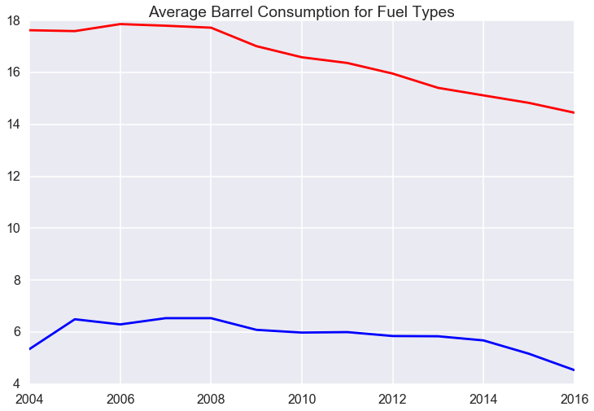

```python
plt.plot(Fuel1Cons_Year, color='red', label='Fuel Type 1')

plt.plot(Fuel2Cons_Year, color='blue', label='Fuel Type 2')

plt.title('Average Barrel Consumption for Fuel Types')
plt.show();
```

Ah, the plot is a little different this time, particularly for Fuel Type 2. This is likely due to the issue we found from the normality plots above: Fuel type 2 data is overrepresented by being given a value of 0, therefore we fixed this by creating a new dataframe that removed the 0 values for both fuel types. Unfortunately, this may create a different type of skewing in our data, and furthermore, the reported data may still be fairly inaccurate.

# Price of Fuel Types

Next we examine the way price changes with each fuel type. My collegues state that cost for fuel type 2 vehicles is far lower than that of fuel type 1 vehicles. Let's see for ourselves if this will hold true.

```python
co2Cost_Year = Data.pivot_table('fuelCost08', index='year') #annual petroleum consumption in barrels for fuelType1 (1)
co2ACost_Year = Data.pivot_table('fuelCostA08', index='year') #annual petroleum consumption in barrels for fuelType2 (1)
```

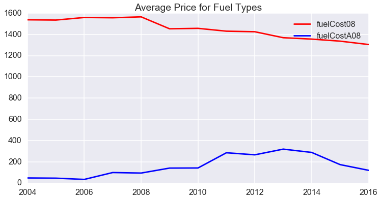

```python
sns.mpl.rc("figure", figsize=(12,6))

plt.plot(co2Cost_Year, color='red')

plt.plot(co2ACost_Year, color='blue')

plt.title('Average Price for Fuel Types')
plt.legend(loc = 'upper right')
plt.show();
```

Does something feel off about this plot? If alternative fuel costs were that low, it would be so ground breaking that we'd all be switching over to alternative fuels immediately. There must be something going on with this data that's skewing the results.

Looking back at the normalized data, remember that the majority of the values for the cost of type 2 fuel is 0. There must be many 0 values in fuel type 2 that is skewing the data. Let's rework our pivoted table of fuel type 2 data and see if we can get a more accurate reading of its true cost.

```python
Fuel1Price_Data = Data[Data.fuelCost08 > 0]
Fuel2Price_Data = Data[Data.fuelCostA08 > 0]
```

```python
co2Cost_Year = Fuel1Price_Data.pivot_table('fuelCost08', index='year')
co2ACost_Year = Fuel2Price_Data.pivot_table('fuelCostA08', index='year')
```

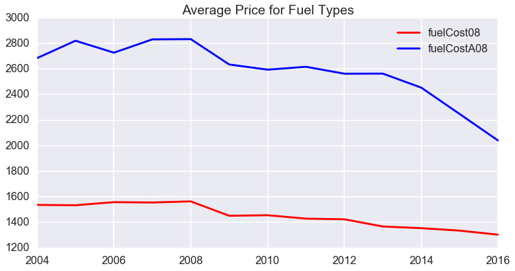

```python
plt.plot(co2Cost_Year, color='red')

plt.plot(co2ACost_Year, color='blue')

plt.title('Average Price for Fuel Types')
plt.legend(loc = 'upper right')
plt.show();
```

The change is as clear as night and data. My collegues were working with a heavily skewed dataset, and the values were so far off that alternative fuels appeared to cost virtually nothing. The reality couldn't be further from the truth.

This makes sense because alternative fuels are so new to our economy. As the years move forward, we are finding increasing innovations to bring the cost of alternative fuels down, making it more competitive with fossil fuels. This peer review reflects that change in our economy, while also showing that th dominant fuel types as well continue to drop in price.

## Analyzing the Price-Consumption Relationship of Fuel Types and Time

I will expand my collegues' report by examining the relationship between price and consumption of each fuel type, and mark each point by its corresponding year to see if there is any significant change in the price-consumption relationship by year.

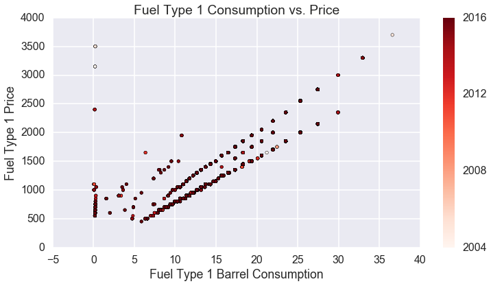

```python
plt.scatter(x = Fuel1Price_Data.barrels08, y = Fuel1Price_Data.fuelCost08, c = Fuel1Price_Data.year, cmap = 'Reds')

plt.xlabel('Fuel Type 1 Barrel Consumption')
plt.ylabel('Fuel Type 1 Price')
plt.title('Fuel Type 1 Consumption vs. Price')
cbar = plt.colorbar()
cbar.set_ticks([2004, 2008,2012, 2016])
plt.show();
```

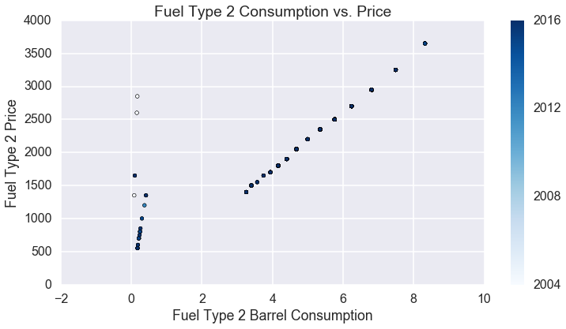

```python
plt.scatter(x = Fuel2Price_Data.barrelsA08, y = Fuel2Price_Data.fuelCostA08, c = Fuel2Price_Data.year, cmap = 'Blues')

plt.xlabel('Fuel Type 2 Barrel Consumption')
plt.ylabel('Fuel Type 2 Price')
plt.title('Fuel Type 2 Consumption vs. Price')
cbar = plt.colorbar()
cbar.set_ticks([2004, 2008,2012, 2016])
plt.show();
```

These visualizations are showing us something counterintuitive. As price goes down, so does consumption, for both fuel types. Why would this be? As a former business student, I know all too well that the energy market does not behave normally (many thanks to OPEC and the corporate oligarchy that controls the energy industry). However, the data conveyed by these visualizations show us a significant positive relationship between price and consumption (as price goes up, so too does consumption). This should not be happening. Perhaps the dataset is faulty, or perhaps there's more going on to this data than meets the eye.

[figure not shown]

```python
fig, ax = plt.subplots(1, 2)

sns.regplot(Fuel1Price_Data.barrels08, Fuel1Price_Data.fuelCost08, c='red', ax=ax[0])

sns.regplot(Fuel2Price_Data.barrelsA08, Fuel2Price_Data.fuelCostA08, c='green', ax=ax[1])

plt.title('Regression Plot of Fuel Type Price vs. Consumption')
plt.show();
```

The regression plot confirms my theory about the positive relationship between fuel price and consumption. I'm beginning to feel skeptical about my findings from this dataset. The reported data does not always match up with reality. In any case, we will move on and leave the questions to the next researcher who comes across this dataset.

# Combined Miles per Gallon

Next I will evaluate my collegues' findings regarding miles per gallon of both fuel types.

```python
Comb1 = Data.pivot_table('comb08', index='year' ) # combined MPG for fuelType1 (2)
Comb2 = Data.pivot_table('combA08', index='year' ) # combined MPG for fuelType2 (2)
```

```python
Comb1.head()
```

```
year
2004    19.575186
2005    19.612328
2006    19.224046
2007    19.231460
2008    19.444978
Name: comb08, dtype: float64
```

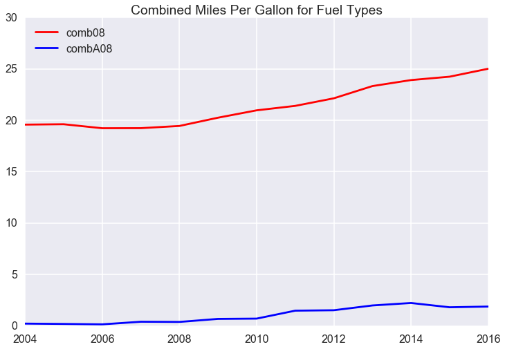

```python
plt.plot(Comb1, color='red')

plt.plot(Comb2, color='blue')

plt.title('Combined Miles Per Gallon for Fuel Types')
plt.legend(loc = 'upper left')
plt.show();
```

Does this plot also seem shocking? Alternative fuel vehicles seem to have unrealistically low miles per gallon, especially considering they're supposed to be the highest MPG vehicles. Let's remove our 0 MPG values (because I'm fairly certain there are no vehicles on the market with 0 MPG) and plot this again.

```python
Fuel1MPG_Data = Data[Data.comb08 > 0]
Fuel2MPG_Data = Data[Data.combA08 > 0]
```

```python
Comb1 = Fuel1MPG_Data.pivot_table('comb08', index='year' ) # combined MPG for fuelType1 (2)
Comb2 = Fuel2MPG_Data.pivot_table('combA08', index='year' ) # combined MPG for fuelType2 (2)
```

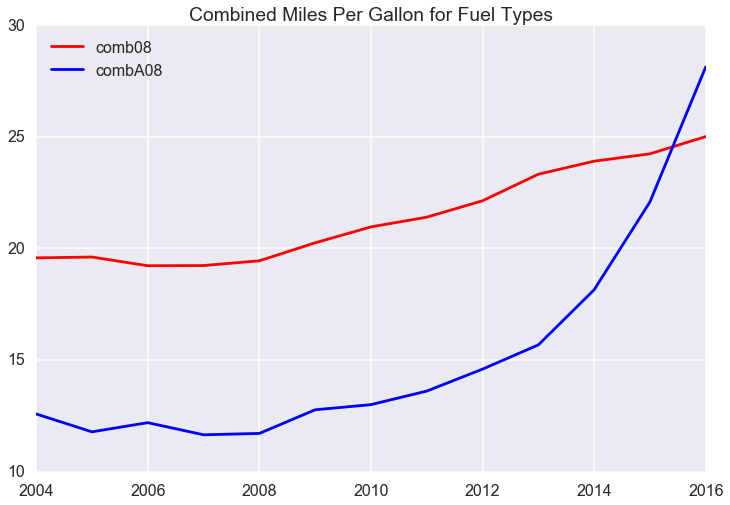

```python
plt.plot(Comb1, color='red')

plt.plot(Comb2, color='blue')

plt.title('Combined Miles Per Gallon for Fuel Types')
plt.legend(loc = 'upper left')
plt.show();
```

This is interesting to look at! Again, alternative fuels seem to be excelling past fossil fuels in their efficiency as the years move forward. However, does the plot still look accurate? 2004 starts with an average MPG of around 12 for alternative fuel vehicles. That still seems fairly low. In the end, I'm not comfortable enough to make conclusions about the efficiency of these two fuel types because I simply don't trust the dataset that I'm working with.

# CO2 Emissions

Finally we're getting to the core of my collegues' report. The visualizations by my collegues suggested that alternative fuels have far fewer emissions than type 1 fuels. However, my collegues later rport that the CO2 data is heavily skewed by -1 values for most observations. We will follow my collegues' steps and see if we can make anything useful out of this data feature.

```python
Carbon1 = Data.pivot_table('co2', index='year')  # co2 - tailpipe CO2 in grams/mile for fuelType1 (5)
Carbon2 = Data.pivot_table('co2A', index='year')  # co2A - tailpipe CO2 in grams/mile for fuelType2 (5)
```

```python
Carbon1.head()
```

```
year
2004   -1
2005   -1
2006   -1
2007   -1
2008   -1
Name: co2, dtype: float64
```

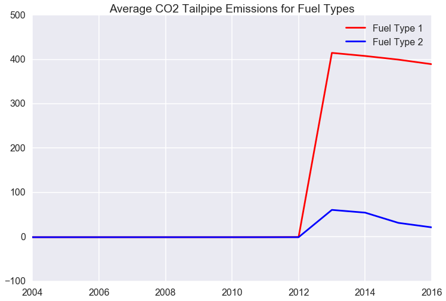

```python
plt.plot(Carbon1, color='red', label='Fuel Type 1')

plt.plot(Carbon2, color='blue', label = 'Fuel Type 2')

plt.title('Average CO2 Tailpipe Emissions for Fuel Types')
plt.legend(loc = 'upper right')
plt.show();
```

As the previous report rightfully pointed out, there appears to be an issue with the way the data is reporting co2 emissions. Going through the datset, we find that most values for both co2 and co2A are -1 (each observation, vehicle model, is procuding less than 0 carbon emissions from its tailpipe). This is a clear inaccuracy, and unfortunately will damage the validity of our report's conclusions.

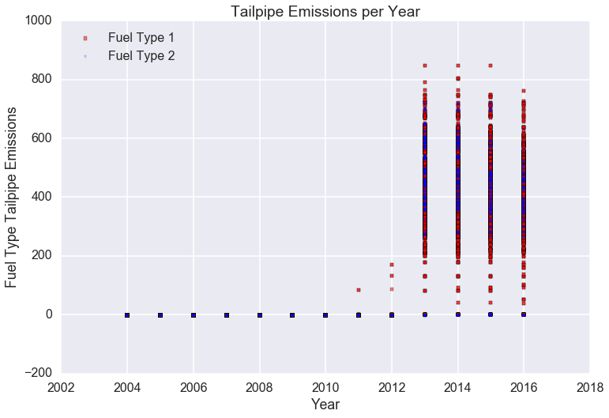

```python
plt.scatter(x = Data.year, y = Data.co2, c = 'red', marker = 's', alpha = 0.5, label='Fuel Type 1')
plt.scatter(x = Data.year, y = Data.co2A, c = 'blue', marker = '+', alpha = 0.7, label='Fuel Type 2')

plt.legend(loc='upper left')
plt.xlabel('Year')
plt.ylabel('Fuel Type Tailpipe Emissions')
plt.title('Tailpipe Emissions per Year')
plt.show();
```

Removing all co2 and co2A values that fall <= 0 will not help us in visualizing the difference between fuel types. The first issue is that it will effectively remove data from all the yesrs up to 2011, and therefore we will not have enough data to make an accurate claim. The next issue is that some Fuel Type 2 vehicals may produce 0 tailpipe emissions, and removing those from our visualized data will effectively skew our visualization and analysis into something inaccurate. My collegue's report seemed to be right to discontinue its visual analysis into carbon emissions of the two fuel types because the data appears to be too inaccurate to work with. Soon, we will fit models onto the CO2 data and evaluate their findings.

# Digging Deeper

With more time put in, the report could expand its analysis to examine the relationships with the dataset's categorical features. From looking through the data, I see drive, fuelType, make, model, trany, and VClass as potential dimensions that we can explore more thoroughly to see their relationships with each fuel type.

```python
print('Fuel types:', pd.unique(Data.fuelType))
print('\n')

print('Vehicle make:', pd.unique(Data.make))
print('\n')

print('Vehicle model:', pd.unique(Data.model))
print('\n')

print('Vehicle transmission:', pd.unique(Data.trany))
print('\n')

print('Vehicle size class:', pd.unique(Data.VClass))
```

```
Fuel types: ['Premium' 'Regular' 'Diesel' 'CNG' 'Gasoline or natural gas'
 'Gasoline or E85' 'Premium or E85' 'Midgrade' 'Electricity'
 'Premium Gas or Electricity' 'Regular Gas and Electricity'
 'Premium and Electricity' 'Regular Gas or Electricity']


Vehicle make: ['Acura' 'Audi' 'BMW' 'Cadillac' 'Chevrolet' 'Chrysler' 'Dodge' 'Ferrari'
 'Ford' 'Honda' 'Lamborghini' 'Lotus' 'Maserati' 'Mazda' 'Mercedes-Benz'
 'Nissan' 'Porsche' 'Toyota' 'Aston Martin' 'Jaguar' 'Lexus' 'MINI'
 'Mitsubishi' 'Volkswagen' 'Hyundai' 'Roush Performance' 'Saab' 'Subaru'
 'Scion' 'Volvo' 'Bentley' 'Daewoo' 'Infiniti' 'Kia' 'Oldsmobile' 'Pontiac'
 'Saturn' 'Suzuki' 'Buick' 'Lincoln' 'Mercury' 'Rolls-Royce' 'Maybach'
 'GMC' 'Isuzu' 'Jeep' 'Land Rover' 'Spyker' 'Hummer' 'Bugatti' 'BMW Alpina'
 'Shelby' 'Saleen Performance' 'smart' 'Tecstar, LP' 'Mahindra' 'Fiat'
 'Azure Dynamics' 'McLaren Automotive' 'VPG' 'Ram' 'CODA Automotive'
 'Fisker' 'Tesla' 'BYD' 'SRT' 'Mobility Ventures LLC' 'Alfa Romeo' 'Pagani']


Vehicle model: ['NSX' 'TT Roadster' 'TT Roadster quattro' ..., 'CT6 AWD'
 'Murano Hybrid FWD' 'Murano Hybrid AWD']


Vehicle transmission: ['Automatic (S4)' 'Manual 6-spd' 'Automatic (S6)' 'Manual 5-spd'
 'Automatic (S5)' 'Automatic 5-spd' 'Automatic 4-spd'
 'Automatic (variable gear ratios)' 'Automatic 7-spd' 'Automatic 6-spd'
 'Automatic (S7)' 'Automatic (S8)' 'Automatic (AM5)' 'Auto(AM6)'
 'Auto(AV-S7)' 'Automatic (AV-S6)' 'Automatic (AM6)' 'Manual 7-spd'
 'Auto(AM7)' 'Automatic (A6)' 'Auto (AV-S6)' 'Auto(AM5)' 'Auto(AV-S6)'
 'Auto (AV-S8)' 'Automatic 8-spd' 'Auto(AV-S8)' 'Auto(A8)' 'Automatic (A1)'
 'Auto (AV)' 'Automatic (AV)' 'Auto(AM-S6)' 'Auto(AM-S7)' 'Automatic 6spd'
 'Automatic 9-spd' 'Automatic (S9)' 'Auto(AM-S8)' 'Auto(A1)' 'Auto(AM8)'
 'Manual(M7)']


Vehicle size class: ['Two Seaters' 'Minicompact Cars' 'Subcompact Cars' 'Compact Cars'
 'Midsize Cars' 'Large Cars' 'Small Station Wagons'
 'Midsize Station Wagons' 'Standard Pickup Trucks 2WD'
 'Standard Pickup Trucks 4WD' 'Vans, Cargo Type' 'Vans, Passenger Type'
 'Minivan - 2WD' 'Minivan - 4WD' 'Sport Utility Vehicle - 2WD'
 'Sport Utility Vehicle - 4WD' 'Small Pickup Trucks 2WD'
 'Small Pickup Trucks 4WD' 'Special Purpose Vehicle 2WD'
 'Small Sport Utility Vehicle 4WD' 'Standard Sport Utility Vehicle 2WD'
 'Standard Sport Utility Vehicle 4WD' 'Small Sport Utility Vehicle 2WD'
 'Special Purpose Vehicle 4WD']
```

```python
from sklearn.preprocessing import LabelEncoder
le = LabelEncoder()

FuelType_Num = Data['fuelType'].value_counts()
Make_Num = Data['make'].value_counts()
Model_Num = Data['model'].value_counts()
Tran_Num = Data['trany'].value_counts()
VClass_Num = Data['VClass'].value_counts()
```

```python
FuelType_Num
```

```
Regular                        15107
Premium                        11455
Gasoline or E85                 1657
Diesel                           384
Premium or E85                   202
Midgrade                         143
Electricity                      141
Premium Gas or Electricity        39
CNG                               36
Premium and Electricity           28
Regular Gas and Electricity       27
Gasoline or natural gas           10
Regular Gas or Electricity         4
Name: fuelType, dtype: int64
```

In my peer review I will only look at one categorical feature: Fuel Type. This feature breaks down into all the specific types of fuels, corresponding either to fuel type 1 or fuel type 2. Let's take a look at what it shows us.

```python
Data['FuelType_Num'] = FuelType_Num
```

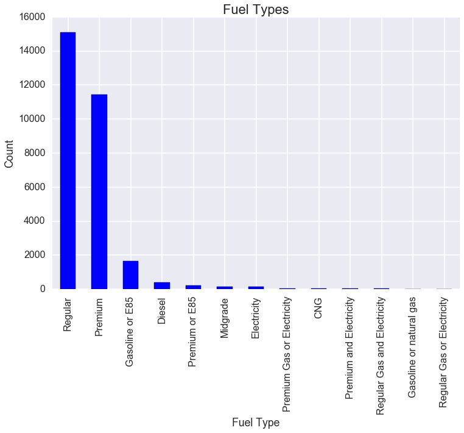

```python
sns.mpl.rc("figure", figsize=(12,8))

FuelType_Num.plot(kind='bar')
plt.xlabel('Fuel Type')
plt.ylabel('Count')
plt.title('Fuel Types', size=22)
plt.show();
```

As we can see, regular and premium fuels (Fuel Type 1) dominate the market. We will look at each fuel type's relationship with miles per gallon, because it is a feature that indicates how efficient each fuel type is, and the feature appears to be somewhat reliable compared to the others in our dataset.

[figure not shown]

```python
sns.boxplot(x ='fuelType', y ='comb08', data = Data, palette="Accent")
sns.stripplot(x="fuelType", y="comb08", data=Data, jitter=True, alpha=0.05, palette="Accent", linewidth=0)

plt.title('Fuel Type vs. Combined MPG, Type 1')
plt.xlabel('Fuel Types')
plt.ylabel('Combined MPG')
plt.xticks(rotation=90)
plt.show();
```

[figure not shown]

```python
sns.boxplot(x ='fuelType', y ='combA08', data = Data, palette="Accent")
sns.stripplot(x="fuelType", y="combA08", data=Data, jitter=True, alpha=0.05, palette="Accent", linewidth=0)

plt.title('Fuel Type vs. Combined MPG, Type 1')
plt.xlabel('Fuel Types')
plt.ylabel('Combined MPG')
plt.xticks(rotation=90)
plt.show();
```

Due to the overlaying of both fuel type 1 data and fuel type 2 data, we have observations of fuel types incorrectly represented in our two box plots (such as electricity represented in our MPG type 1 box plot). Nonetheless, we have an indicator that alternative fuels generally appear to be more efficient than fossil fuels.

```python
Fuels_Rel = Data.pivot_table(values='comb08', index='year', columns='fuelType', aggfunc=np.median)
```

```python
Fuels_RelA = Data.pivot_table(values='combA08', index='year', columns='fuelType', aggfunc=np.median)
```

[figure not shown]

```python
sns.heatmap(Fuels_Rel, cmap= 'RdYlBu', annot= True, fmt=',.0f', annot_kws={'fontsize':14})

plt.title('MPG of Fuel Type by Year')
plt.show();
```

[figure not shown]

```python
sns.heatmap(Fuels_RelA, cmap= 'RdYlBu', annot= True, fmt=',.0f', annot_kws={'fontsize':14})

plt.title('MPG of Fuel Type 2 by Year')
plt.show();
```

Again we have the same representation issue. That being said, if we look at the second heat map, we see that our alternative fuels appear to beat out our fossil fuels overall in efficiency.

# Evaluating the Model

For the last step, my review will evaluate the effectiveness of my collegues' logistic regression model. The model is useful in predicting vehicles with high CO2 emissions, using fuel price, consumption, and MPG as predictor X features.

We will start off by replicating the logistic model:

```python
Data_Hi = Data[['co2','barrels08','fuelCost08', 'comb08', 'fuelType']]
Data_Hi2 = Data[['co2A','barrels08','fuelCost08', 'comb08', 'fuelType']]

Data_Hi['co2_high'] = Data_Hi.co2 > 334
Data_LowCount = int(len(Data_Hi[Data_Hi['co2_high']]) * .30)
Data_LowInd = np.random.choice(Data_Hi[~Data_Hi['co2_high']].index, size=Data_LowCount, replace=False)
Data_HiSubset = Data_Hi.iloc[np.concatenate((Data_LowInd, Data_Hi[Data_Hi['co2_high']].index))]
# Contronling for the -1 values that make up for more 50% of our data before we plot our model
Data_HiSubset = Data_HiSubset[(Data_HiSubset.co2 > 200 )]
Data_Hi = Data_Hi[(Data_Hi.co2 >= 200 )]

Data_Hi = pd.get_dummies(Data_Hi)
Data_HiSubset = pd.get_dummies(Data_HiSubset)
Data_Hi.co2_high.value_counts()
```

```
True     7515
False    2529
Name: co2_high, dtype: int64
```

```python
from sklearn import linear_model
Model = linear_model.LogisticRegression(C=18)
Model.fit(Data_HiSubset.drop(['co2_high', 'co2'], axis=1), Data_HiSubset['co2_high']) # X and Y for the model
Data_Hi['co2_High_pred'] = Model.predict(Data_Hi.drop(['co2_high', 'co2'], axis=1))
```

```python
Data_Hi.head()
```

|  | co2 | barrels08 | fuelCost08 | comb08 | co2_high | fuelType_CNG | fuelType_Diesel | fuelType_Gasoline or E85 | fuelType_Gasoline or natural gas | fuelType_Midgrade | fuelType_Premium | fuelType_Premium Gas or Electricity | fuelType_Premium and Electricity | fuelType_Premium or E85 | fuelType_Regular | co2_High_pred |
| --- | --- | --- | --- | --- | --- | --- | --- | --- | --- | --- | --- | --- | --- | --- | --- | --- |
| 18852 | 471 | 17.337486 | 1750 | 19 | True | 0 | 0 | 0 | 0 | 0 | 1 | 0 | 0 | 0 | 0 | True |
| 18853 | 471 | 17.337486 | 1750 | 19 | True | 0 | 0 | 0 | 0 | 0 | 1 | 0 | 0 | 0 | 0 | True |
| 18854 | 349 | 13.184400 | 1350 | 25 | True | 0 | 0 | 0 | 0 | 0 | 1 | 0 | 0 | 0 | 0 | True |
| 18855 | 349 | 13.184400 | 1350 | 25 | True | 0 | 0 | 0 | 0 | 0 | 1 | 0 | 0 | 0 | 0 | True |
| 18856 | 429 | 15.689436 | 1600 | 21 | True | 0 | 0 | 0 | 0 | 0 | 1 | 0 | 0 | 0 | 0 | True |

## Making Some Changes

While my collegues do not report an accuracy score from their model, it appears to have quite high accuracy, particularly when looking at the confusion matrix they made to report their true positives, true negatives, false positives, and false negatives. There's one problem I see with my collegues' model: it is accurate to the training data, but may not be accurate to reality. We will evaluate their model by testing its bias-variance tradeoff to determine if it should fit with unseen data or not. In the following steps, I will take the data and partition it into train and test sets, and evlauate the effectiveness of the model through visualized hyperparameter tuning.

```python
Data_Prep = Data_Hi.drop(['co2_high', 'co2', 'co2_High_pred'], axis=1)
Data_Prep.head(3)
```

|  | barrels08 | fuelCost08 | comb08 | fuelType_CNG | fuelType_Diesel | fuelType_Gasoline or E85 | fuelType_Gasoline or natural gas | fuelType_Midgrade | fuelType_Premium | fuelType_Premium Gas or Electricity | fuelType_Premium and Electricity | fuelType_Premium or E85 | fuelType_Regular |
| --- | --- | --- | --- | --- | --- | --- | --- | --- | --- | --- | --- | --- | --- |
| 18852 | 17.337486 | 1750 | 19 | 0 | 0 | 0 | 0 | 0 | 1 | 0 | 0 | 0 | 0 |
| 18853 | 17.337486 | 1750 | 19 | 0 | 0 | 0 | 0 | 0 | 1 | 0 | 0 | 0 | 0 |
| 18854 | 13.184400 | 1350 | 25 | 0 | 0 | 0 | 0 | 0 | 1 | 0 | 0 | 0 | 0 |

```python
X = Data_Prep.values
y = Data_Hi['co2_high'].values
le = LabelEncoder()
y = le.fit_transform(y)
```

```python
#To see how our data will be represented
le.transform([True, False])
```

```
array([1, 0])
```

```python
y
```

```
array([1, 1, 1, ..., 0, 0, 0])
```

```python
from sklearn.cross_validation import train_test_split
X_train, X_test, y_train, y_test = train_test_split(X, y, test_size=0.2, random_state=1)
```

### Combine Transformers and Estimators in a Pipeline

Many learning algorithms require input features on the same scale of optimal performance, so we need to standardize the columns of the dataset before we feed them to a linear classifier. Furthermore, if we want to compress our data into a lower dimensional subspace via Principal Component Analysis (PCA), rather than going through the fitting and transformation steps before, we can chain the standard scalar PCA and Logistic Regression objects in a pipeline:

```python
from sklearn.preprocessing import StandardScaler
from sklearn.decomposition import PCA
from sklearn.linear_model import LogisticRegression
from sklearn.pipeline import Pipeline

pipe_lr = Pipeline([('scl', StandardScaler()), ('pca', PCA(n_components=2)),
                    ('clf', LogisticRegression(random_state=1))])
pipe_lr.fit(X_train, y_train)
print('Test Accuracy: %.3f' % pipe_lr.score(X_test, y_test))
```

```
Test Accuracy: 0.979
```

Pretty high accuracy, right? Unfortunately we can't accept this accuracy score to reflect a real model at face value. We need to account for a bias-variance tradeoff that will occur when modelling unseen data. If we model a learning curve to our data, we can create a visualization to estimate the difference between our model's accuracy with the training set, and its accuracy with an unseen validation set. Furthermore, it will also show us the difference between accuracies as samples increase.

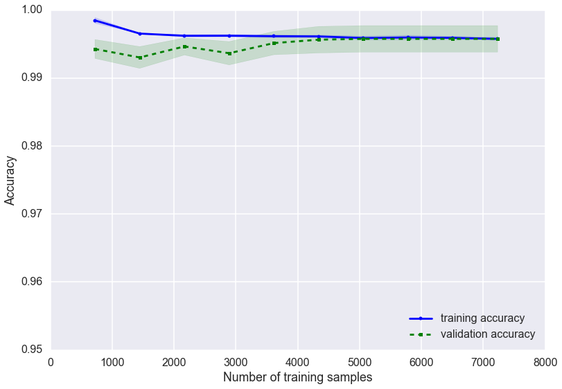

```python
from sklearn.learning_curve import learning_curve

pipe_lr = Pipeline([
        ('scl', StandardScaler()),
        ('clf', LogisticRegression(penalty='l2', random_state=0))])
train_sizes, train_scores, test_scores = learning_curve(estimator = pipe_lr, X = X_train, y = y_train,
                                                        train_sizes = np.linspace(0.1, 1, 10), cv = 10, n_jobs = 1)
train_mean = np.mean(train_scores, axis=1)
train_std = np.std(train_scores, axis=1)
test_mean = np.mean(test_scores, axis=1)
test_std = np.std(test_scores, axis=1)

plt.plot(train_sizes, train_mean, color='blue', marker='o', markersize=5, label='training accuracy')
plt.fill_between(train_sizes, train_mean + train_std, train_mean - train_std, alpha=0.15, color='blue')
plt.plot(train_sizes, test_mean, color='green', linestyle='--', marker='s', markersize=5, label='validation accuracy')
plt.fill_between(train_sizes, test_mean + test_std, test_mean - test_std, alpha=0.15, color='green')

plt.xlabel('Number of training samples')
plt.ylabel('Accuracy')
plt.legend(loc="lower right")
plt.ylim([0.95, 1.0])
plt.show()
```

Our estimation gives us excellent news: the model's predictions should be nearly the same between its test predictions and validation predictions. The high accuracy level and low difference between data type predictions indicates that my collegues' model does not suffer from either high variance or high bias.

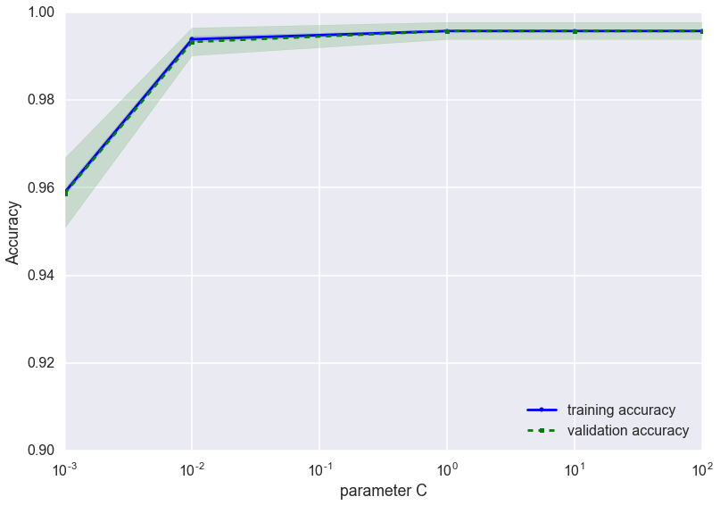

```python
from sklearn.learning_curve import validation_curve

param_range = [0.001, 0.01, 0.01, 1.0, 10.0, 100.0]
train_scores, test_scores = validation_curve(estimator = pipe_lr, X = X_train, y = y_train, param_name = 'clf__C',
                                             param_range = param_range, cv = 10)
train_mean = np.mean(train_scores, axis=1)
train_std = np.std(train_scores, axis=1)
test_mean = np.mean(test_scores, axis=1)
test_std = np.std(test_scores, axis=1)

plt.plot(param_range, train_mean, color='blue', marker='o', markersize=5, label='training accuracy')
plt.fill_between(param_range, train_mean + train_std, train_mean - train_std, alpha = 0.15, color='blue', )
plt.plot(param_range, test_mean, linestyle='--', color='green', marker='s', markersize=5, label='validation accuracy')
plt.fill_between(param_range, test_mean + test_std, test_mean - test_std, alpha=0.15, color='green')

plt.xscale('log')
plt.legend(loc='lower right')
plt.xlabel('parameter C')
plt.ylabel('Accuracy')
plt.ylim([0.9, 1])
plt.show()
```

## Confusion Matrix

To finish the evaluation, I will implement my own confusion matrix and tweak it to appear more viewer friendly using scikit-learn's *confusion_matrix* object. First I will replicate my collegues' matrix:

```python
Data_Hi[['co2_high', 'co2_High_pred']].apply(pd.value_counts)
```

|  | co2_high | co2_High_pred |
| --- | --- | --- |
| True | 7515 | 7578 |
| False | 2529 | 2466 |

Now to implement my own to the model I made, and tweak it to be more viewer friendly.

```python
from sklearn.metrics import confusion_matrix

pipe_lr.fit(X_train, y_train)
y_pred = pipe_lr.predict(X_test)
confmat = confusion_matrix(y_true=y_test, y_pred=y_pred)
print(confmat)
```

```
[[ 498   11]
 [   0 1500]]
```

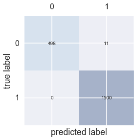

```python
fig, ax = plt.subplots(figsize=(5, 5))
ax.matshow(confmat, cmap=plt.cm.Blues, alpha=0.3)
for i in range(confmat.shape[0]):
    for j in range(confmat.shape[1]):
        ax.text(x=j, y=i, s=confmat[i, j], va='center', ha='center')
plt.xlabel('predicted label')
plt.ylabel('true label')
plt.show();
```

# Conclusions

My collegues' report takes us to the beginning of an important discovery of the relationships between fossil and alternative fuels. Their report is successful at giving us an overview of the two fuel types' relationships together, and how the change with different features. It also provides helpful time series visualizations of these relationships and how they change by year. The report also utilizes bar, violin, and jitter plots effectively to convey the differences in data distributions for both fuel types. Finally, they successfully build a logistic model that accurately predicts vehicle types with high CO2 emissions, which is as accurate with unseen data as it is with training data. Some areas where their report falls short pertain to the datasets poorly distributed data, and how it skews their visualizations, and not digging deeper into the relationships to categorical features such as the specific fuel types.

Unfortunately, our collegues could not conclude whether or not their hypothesis that fuel type 1 vehicles prodice more CO2 emissions that fuel type 2 vehicles, due to an inadequate dataset. This peer review cannot further test their hypothesis as well due to the dataset.